## Week 5

### Introduction

The fifth week of the course focuses on different dimension reduction techniques. I will be using Principal Component Analysis (PCA) and Multiple Correspondence Analysis (MCA). For practicing these methods, I am doing a few tasks with the United Nations Development Programme data from Human Development Index (HDI) and Gender Inequality Index (GII) databases. The data covers countries across the globe. Metadata are available [here](http://hdr.undp.org/en/content/human-development-index-hdi).

### Graphical overview

```r
library(openxlsx)
setwd("~/IODS-project/data/")
human <- read.xlsx("human.xlsx")

library(GGally)
library(tidyverse)
library(corrplot)
summary(human)
```

```
##    edu_ratio        lab_ratio         exp_edu         life_exp
##  Min.   :0.1717   Min.   :0.1857   Min.   : 5.40   Min.   :49.00
##  1st Qu.:0.7264   1st Qu.:0.5984   1st Qu.:11.25   1st Qu.:66.30
##  Median :0.9375   Median :0.7535   Median :13.50   Median :74.20
##  Mean   :0.8529   Mean   :0.7074   Mean   :13.18   Mean   :71.65
##  3rd Qu.:0.9968   3rd Qu.:0.8535   3rd Qu.:15.20   3rd Qu.:77.25
##  Max.   :1.4967   Max.   :1.0380   Max.   :20.20   Max.   :83.50
##       gni          maternal_mx      teen_births      female_parl
##  Min.   :   581   Min.   :   1.0   Min.   :  0.60   Min.   : 0.00
##  1st Qu.:  4198   1st Qu.:  11.5   1st Qu.: 12.65   1st Qu.:12.40
##  Median : 12040   Median :  49.0   Median : 33.60   Median :19.30
##  Mean   : 17628   Mean   : 149.1   Mean   : 47.16   Mean   :20.91
##  3rd Qu.: 24512   3rd Qu.: 190.0   3rd Qu.: 71.95   3rd Qu.:27.95
##  Max.   :123124   Max.   :1100.0   Max.   :204.80   Max.   :57.50
```

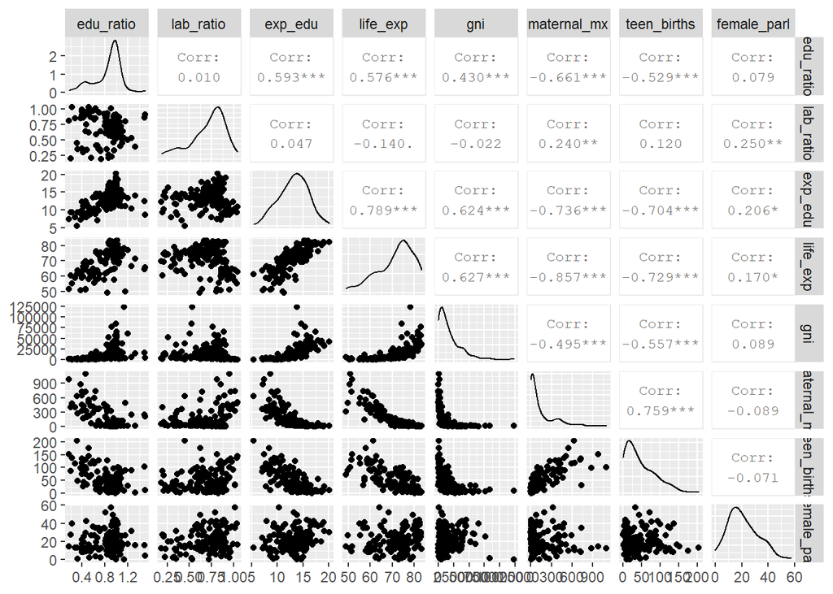

```r
ggpairs(human,
        upper = list(continuous =
                       wrap("cor", size =
                              3)))
```

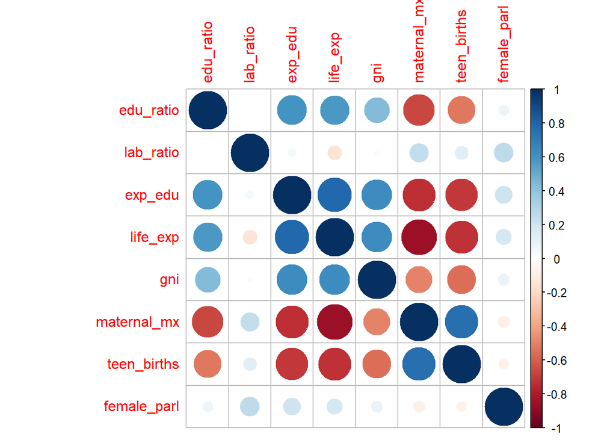

```r
corrplot(cor(human))
```

We can start to identify associations between these variables from the *ggpairs* output and the correlation plot above. First, we see that the demographic indicators, overall life expectancy, maternal mortality rate and teen birth rate are strongly correlated. These are also correlated with the GNI, the expected number of years of education and gender equality in education. Life expectancy is correlated positively with these indicators, whereas maternal mortality and teen births negatively.Gender equality in the labour force or in the parliament does not seem to have strong correlations with any of the variables.

### Principal component analysis

Given that the data used describes multiple aspects of societies, identifying bivariate associations is somewhat uninteresting. Therefore, I will perform a PCA to identify whether the indicators presented above belong to same dimensions and if the dimensions have meaningful relationships between each other. I will start by running the analysis on unmodified data.

```r
#PCA
pca_human <- prcomp(human)
#summary
summary(pca_human)
```

```
## Importance of components:
##                              PC1      PC2   PC3   PC4   PC5   PC6    PC7    PC8
## Standard deviation     1.854e+04 185.5219 25.19 11.45 3.766 1.566 0.1912 0.1591
## Proportion of Variance 9.999e-01   0.0001  0.00  0.00 0.000 0.000 0.0000 0.0000
## Cumulative Proportion  9.999e-01   1.0000  1.00  1.00 1.000 1.000 1.0000 1.0000
```

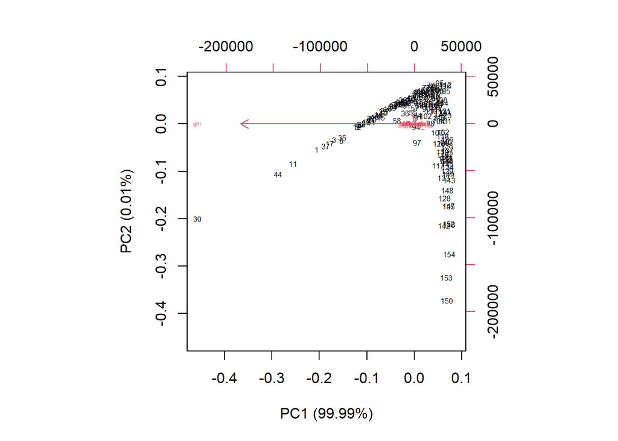

PCA with unstandardized data. GNI explains all of the variability

```r
#Save proportions of variance explained
proportions <-
  round(
    summary(pca_human)$importance[2,]*100,
    digits=3)

pc_lab <-
  paste0(
  names(proportions)," (", proportions, "%)")
#biplot
biplot(pca_human,
       choices=1:2,
       cex=c(0.5,0.4),
       xlab=pc_lab[1],
       ylab=pc_lab[2])
```

Okay then, from the summary of the model we see that the model identified 8 principle components (which is the number ofthe variables) but the first of these explains 99.99%=100% of the variation in the data. If we look at the biplot, we can see that the only important component seems to be the gross national income (I guess many politicians use this type of PCA in their reasonings). The fact that GNI overrides all the other variables is related to the fact that in th unmodified data, all the variables have different variances and the PCA treats the variable with the largest variance as the most important one. Therefore, to actually identify the real dimensions, I need to scale the data and run the analysis again.

```r
#scale data
human_sc <- scale(human)

pca_human_sc <- prcomp(human_sc)

summary(pca_human_sc)
```

```
## Importance of components:
##                           PC1    PC2     PC3     PC4     PC5     PC6     PC7
## Standard deviation     2.0708 1.1397 0.87505 0.77886 0.66196 0.53631 0.45900
## Proportion of Variance 0.5361 0.1624 0.09571 0.07583 0.05477 0.03595 0.02634
## Cumulative Proportion  0.5361 0.6984 0.79413 0.86996 0.92473 0.96069 0.98702
##                            PC8
## Standard deviation     0.32224
## Proportion of Variance 0.01298
## Cumulative Proportion  1.00000
```

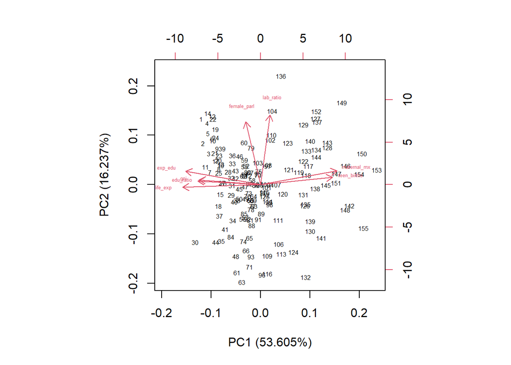

PCA with scaled data. First principal component measuring overall economic and vital well-being, second gender equality

```r
proportions <-
  round(
    summary(pca_human_sc)$importance[2,]*100,
    digits=3)

pc_lab <-
  paste0(
  names(proportions)," (", proportions, "%)")

biplot(pca_human_sc,
       choices=1:2,
       cex=c(0.5,0.4),
       xlab=pc_lab[1],
       ylab=pc_lab[2])
```

Now, a much more interesting plot is produced. We can see that the sociodemographic indicators education, GNI, life expectancy, maternal mortality and teen births load to the first principal component. That component explains over 50% of the total variability in the data. We also see that maternal mortality and teen births operate to an opposite direction when compared to the other factors. These makes sense as it would be weird if for instance GNI would increase with increasing rates of maternal mortality and teen births. These correlations were already identified above in the graphical overview step.

Second, the new PCA produced another distinct principal component, which seems to describe gender equality. The gender ratio at the labour market and proportion of females in parliament relate to this component. This dimension seems to be genuinely distinct from the first as the variables related to this component have almost 90 degree angle (meaning low correlation) in the arrows when compared to the indicators influencing dimension one.I might interpret this to indicate that gender equality in labour market and parliament is not related to economic and “vital” well-being in the society.Instead, other factors (maybe values, attitudes etc.) are at play. A surprising thing is that the gender equality in education seems not to belong to the gender equality component. However, this is probably because the variable only includes information on secondary education. It might be that for overall increases well-being, it is necessary to have a population where each member has at least some education. Differences might occur if tertiary education was used as the measure of education.

### Multiple Correspondence Analysis

As the second part of this assignment, I am implementing the MCA to a pre-existing dataset called [*tea*](https://rdrr.io/cran/FactoMineR/man/tea.html), available in R package *FactoMineR*. The data contains information of tea drinking habits of 300 individuals. I chose 6 first variables from the data set that measure the time when these people drink tea, and try to identify similar components and in the PCA but this time for categorical data.

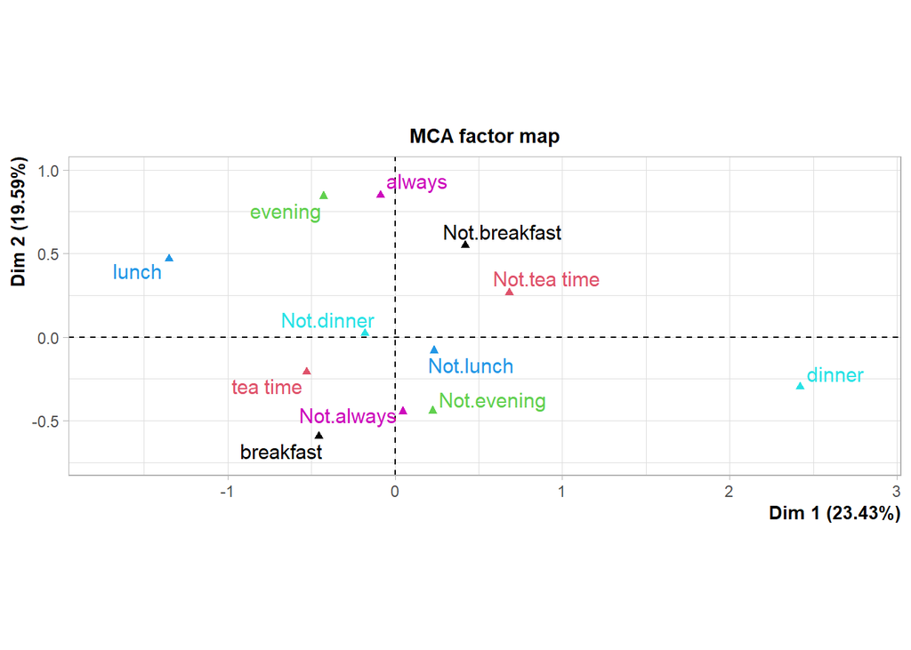

```r
library(FactoMineR)
data(tea)

tea_plc_time <-
  tea[,1:6]

mca <- MCA(tea_plc_time,graph=F)

plot(mca,habillage="quali",invisible=c("ind"))
```

The MCA calculates distances between variables in a three-dimensional space (I think, at least). In the plot above, the distances between the variables at first two-dimensions are plotted. We can see that the variable categories opposite to each other (no/yes) are plotted to opposite quadrants of the plot. Second, we see that similar variables are plotted close to each other (for instance not breakfast and not tea time). Third, the variable categories that are well categorized by the dimensions occur further from the center of the plot than others.We can clearly see that especially dinner and lunch seem to determine to be well distinguished. We can also confirm this by looking at the bar plots of the variables: it is clear that there seems to be a relatively small group of lunch or dinner drinkers.

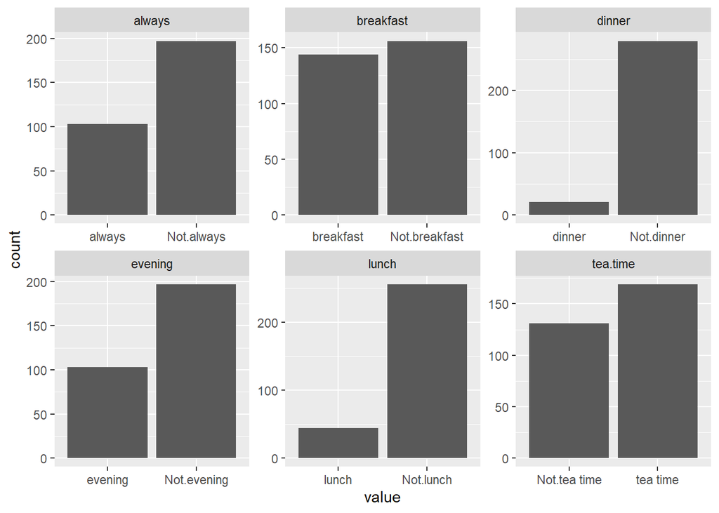

```r
data(tea)

gather(tea[,1:6]) %>%
  ggplot(aes(value)) +
  facet_wrap("key",scales="free") +
  geom_bar()
```

Let’s continue the analysis by adding the individuals to the plot:

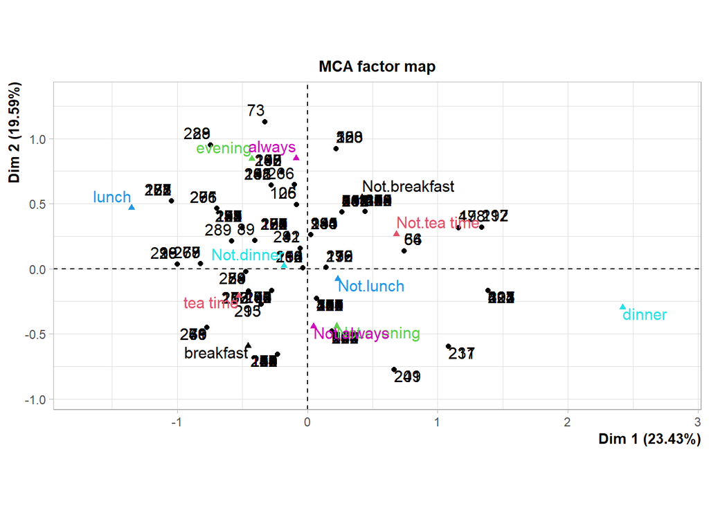

```r
plot(mca,habillage="quali")
```

Now, we have plotted in the upper left corner the individuals whose tea drinking habits are characterized by drinking tea during lunch and evenings. In th upper right corner we have those individuals who apparently do not drink tea at all (see also the above plot to better see the categories)